# Problemy z czytelnością wykresów

Raport z pracy domowej nr 3

Maciej Orsłowski

## Opis eksperymentu

Eksperyment, który przeprowadziłem w ramach tej pracy domowej miał sprawdzić, czy wykresy kołowe faktycznie są mniej czytelne niż kolumnowe. W tym celu stworzyłem krótką ankietę, którą wypełniło 19 osób w różnym wieku i z różnych środowisk.

Na potrzeby eksperymentu stworzyłem ramkę danych przedstawiającą wyniki I tury wyborów prezydenckich w fikcyjnym kraju i na ich podstawie stworzyłem dwa wykresy - kołowy i kolumnowy:

| Kandydat | Wynik (w %) |
| --- | --- |
| A | 31 |
| B | 30 |
| C | 14 |
| D | 11 |
| E | 7 |
| F | 5 |
| G | 2 |

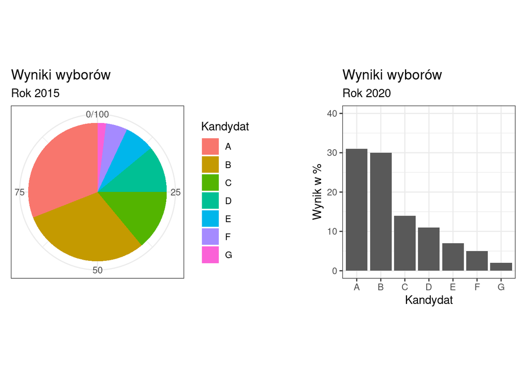

Powyższe wykresy różnią się nieco od tych, które zostały przedstawione ankietowanym - na potrzeby czytelności raportu, kandydatów oznaczyłem literami od A do G w kolejności od najwyższego wyniku do najniższego. Oryginalnie jednak kandydaci posiadali fikcyjne imiona i nazwiska, które różniły się na obu wykresach (podobnie jak rok przeprowadzenia wyborów) - miało to na celu utrudnienie ankietowanym spostrzeżenia, że oba wykresy przedstawiają identyczne dane. Dzięki temu respondenci odpowiadali na pytania pod drugim wykresem nie sugerując się swoimi odpowiedziami pod wykresem pierwszym (pytania pod oboma wykresami były identyczne).

## Wyniki eksperymentu

#### Pytanie nr 1: Oszacuj ile punktów procentowych dzieliło zwycięzcę I tury od kandydata, który zajął drugie miejsce

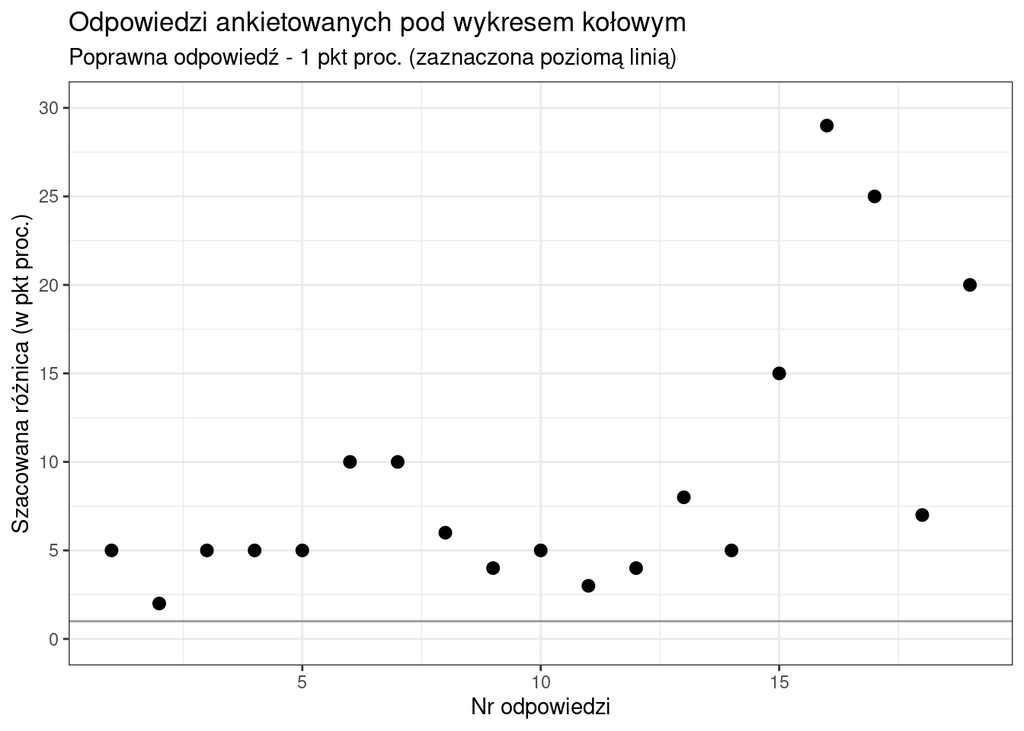

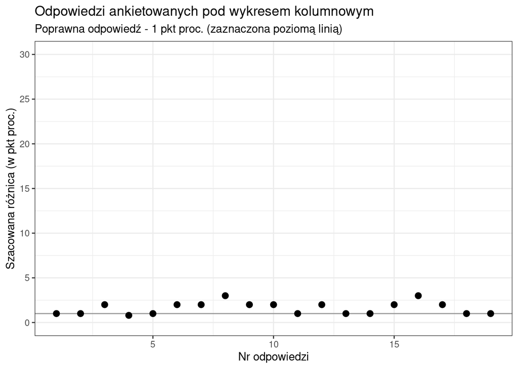

Już na pierwszy rzut oka widać, że pod wykresem kolumnowym szacunki respondentów były znacznie dokładniejsze. Ciekawe jest również to, że na podstawie wykresu kołowego ani jeden ankietowany nie był w stanie podać poprawnej różnicy, natomiast aż 8 z 19 potrafiło tego dokonać pod wykresem kolumnowym. Ponadto, żaden z respondentów odpowiadając pod wykresem kolumnowym nie pomylił się o więcej niż 2 punkty procentowe, podczas gdy pod kołowym jedynie dwie odpowiedzi mieściły się w tym zakresie błędu.

#### Pytanie nr 2: Oszacuj ile razy więcej głosów od kandydata C zdobył kandydat A

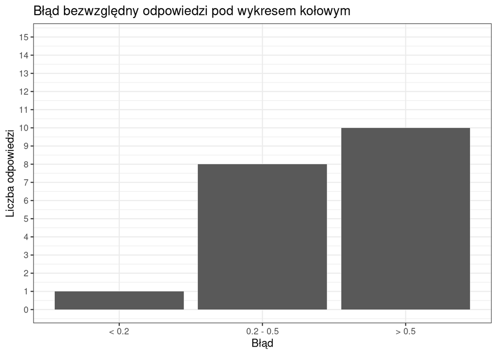

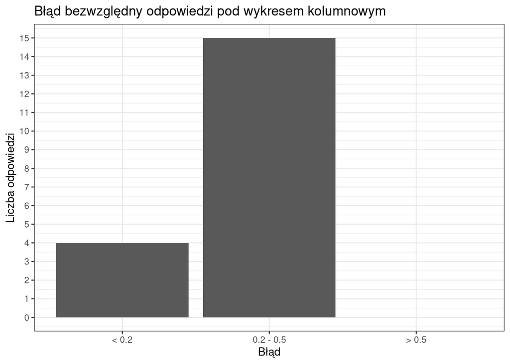

Szacowanie ile razy jedna zmienna jest większa od drugiej samo w sobie jest dość trudne, mimo to także pod tym pytaniem widać, że odpowiedzi pod wykresem kolumnowym były dokładniejsze, niż pod kołowym. Tylko jedna osoba odpowiadając pod wykresem kołowym pomyliła się o mniej niż 0.2, podczas gdy pod wykresem kolumnowym takich osób było 4. Co więcej, żaden z ankietowanych nie pomylił się o więcej niż 0.5 odpowiadając na to pytanie pod wykresem kolumnowym, natomiast aż 10 z 19 popełniło taki lub większy błąd szacując z pomocą wykresu kołowego.

#### Pytanie nr 3: Oszacuj ile procent głosów zdobył kandydat E

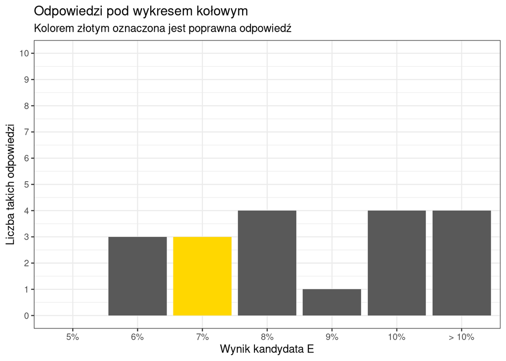

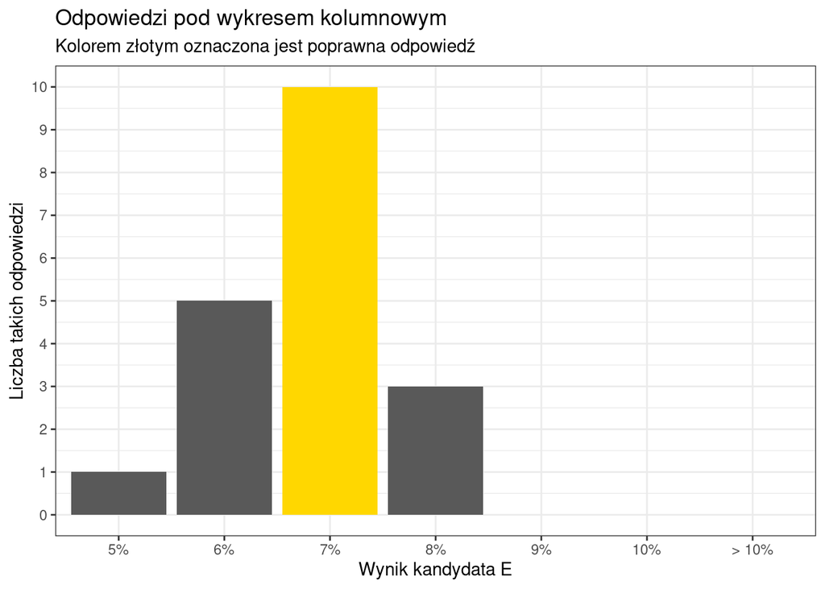

Odpowiedzi na ostatnie pytanie również były mniej dokładne, gdy respondenci szacowali z użyciem wykresu kołowego. W przypadku tego wykresu byli oni dość podzieleni, gdyż jak widać żadna z udzielonych odpowiedzi nie dominuje częstością występowania nad pozostałymi. Co ciekawe, tylko 3 ankietowanych podało odpowiedź mniejszą niż faktyczna wartość, a aż 13 z nich ją przeszacowało. Oznaczać to może, że rozmiary wycinków koła na wykresie zwykle wydają się większe, niż są w rzeczywistości. Pod wykresem kolumnowym natomiast, nieco ponad połowa respondentów (10 z 19) potrafiła poprawnie wskazać wynik uzyskany przez kandydata E. Oprócz tego, tylko jeden ankietowany pomylił się o więcej niż 1 punkt procentowy.

## Wniosek

Niezależnie od tego czy zadanie polegało na oszacowaniu różnicy między dwiema wartościami, to ile razy jedna z nich jest większa od drugiej czy po prostu na odczytaniu danej z wykresu, respondenci znacznie lepiej sobie z nim radzili gdy wspomagali się wykresem kolumnowym. Powyższe wyniki eksperymentu jednoznacznie potwierdzają zatem, że wykresy kołowe znacząco ustępują czytelnością wykresom kolumnowym.